# Simple Linear Regression

> “All models are wrong, but some are useful.”

> — **George E. P. Box**

Suppose you are a car manufacturer.

```r
?cars
```

```r
cars
```

```
##    speed dist
## 1      4    2
## 2      4   10
## 3      7    4
## 4      7   22
## 5      8   16
## 6      9   10
## 7     10   18
## 8     10   26
## 9     10   34
## 10    11   17
## 11    11   28
## 12    12   14
## 13    12   20
## 14    12   24
```

[output cut: 36 more lines]

```r
names(cars)
```

```
## [1] "speed" "dist"
```

```r
str(cars)
```

```
## 'data.frame':    50 obs. of  2 variables:
##  $ speed: num  4 4 7 7 8 9 10 10 10 11 ...
##  $ dist : num  2 10 4 22 16 10 18 26 34 17 ...
```

```r
dim(cars)
```

```
## [1] 50  2
```

```r
nrow(cars)
```

```
## [1] 50
```

```r
ncol(cars)
```

```
## [1] 2
```

```r
stop_dist_model = lm(dist ~ speed, data = cars)
```

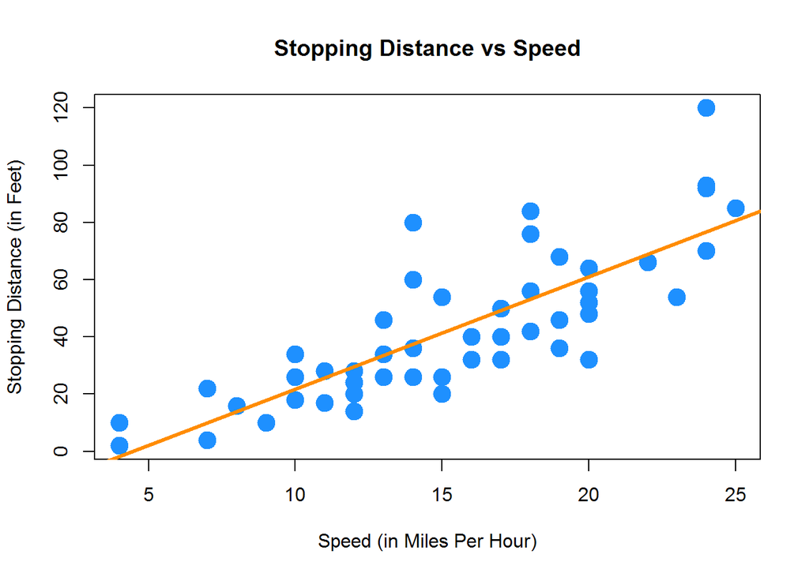

```r
plot(dist ~ speed, data = cars,
     xlab = "Speed (in Miles Per Hour)",
     ylab = "Stopping Distance (in Feet)",
     main = "Stopping Distance vs Speed",
     pch  = 20,
     cex  = 3,
     col  = "dodgerblue")
abline(stop_dist_model, lwd = 3, col = "darkorange")
```

```r
stop_dist_model
```

```
##
## Call:
## lm(formula = dist ~ speed, data = cars)
##
## Coefficients:
## (Intercept)        speed
##     -17.579        3.932
```

```r
names(stop_dist_model)
```

```
##  [1] "coefficients"  "residuals"     "effects"       "rank"
##  [5] "fitted.values" "assign"        "qr"            "df.residual"
##  [9] "xlevels"       "call"          "terms"         "model"
```

```r
stop_dist_model$residuals
```

```
##          1          2          3          4          5          6
##   3.849460  11.849460  -5.947766  12.052234   2.119825  -7.812584
##          7          8          9         10         11         12
##  -3.744993   4.255007  12.255007  -8.677401   2.322599 -15.609810
##         13         14         15         16         17         18
##  -9.609810  -5.609810  -1.609810  -7.542219   0.457781   0.457781
##         19         20         21         22         23         24
##  12.457781 -11.474628  -1.474628  22.525372  42.525372 -21.407036
##         25         26         27         28         29         30
## -15.407036  12.592964 -13.339445  -5.339445 -17.271854  -9.271854
##         31         32         33         34         35         36
##   0.728146 -11.204263   2.795737  22.795737  30.795737 -21.136672
##         37         38         39         40         41         42
## -11.136672  10.863328 -29.069080 -13.069080  -9.069080  -5.069080
##         43         44         45         46         47         48
##   2.930920  -2.933898 -18.866307  -6.798715  15.201285  16.201285
##         49         50
##  43.201285   4.268876
```

```r
coef(stop_dist_model)
```

```
## (Intercept)       speed
##  -17.579095    3.932409
```

```r
resid(stop_dist_model)
```

```
##          1          2          3          4          5          6
##   3.849460  11.849460  -5.947766  12.052234   2.119825  -7.812584
##          7          8          9         10         11         12
##  -3.744993   4.255007  12.255007  -8.677401   2.322599 -15.609810
##         13         14         15         16         17         18
##  -9.609810  -5.609810  -1.609810  -7.542219   0.457781   0.457781
##         19         20         21         22         23         24
##  12.457781 -11.474628  -1.474628  22.525372  42.525372 -21.407036
##         25         26         27         28         29         30
## -15.407036  12.592964 -13.339445  -5.339445 -17.271854  -9.271854
##         31         32         33         34         35         36
##   0.728146 -11.204263   2.795737  22.795737  30.795737 -21.136672
##         37         38         39         40         41         42
## -11.136672  10.863328 -29.069080 -13.069080  -9.069080  -5.069080
##         43         44         45         46         47         48
##   2.930920  -2.933898 -18.866307  -6.798715  15.201285  16.201285
##         49         50
##  43.201285   4.268876
```

```r
fitted(stop_dist_model)
```

```
##         1         2         3         4         5         6         7
## -1.849460 -1.849460  9.947766  9.947766 13.880175 17.812584 21.744993
##         8         9        10        11        12        13        14
## 21.744993 21.744993 25.677401 25.677401 29.609810 29.609810 29.609810
##        15        16        17        18        19        20        21
## 29.609810 33.542219 33.542219 33.542219 33.542219 37.474628 37.474628
##        22        23        24        25        26        27        28
## 37.474628 37.474628 41.407036 41.407036 41.407036 45.339445 45.339445
##        29        30        31        32        33        34        35
## 49.271854 49.271854 49.271854 53.204263 53.204263 53.204263 53.204263
##        36        37        38        39        40        41        42
## 57.136672 57.136672 57.136672 61.069080 61.069080 61.069080 61.069080
##        43        44        45        46        47        48        49
## 61.069080 68.933898 72.866307 76.798715 76.798715 76.798715 76.798715
##        50
## 80.731124
```

```r
summary(stop_dist_model)
```

```
##
## Call:
## lm(formula = dist ~ speed, data = cars)
##
## Residuals:
##     Min      1Q  Median      3Q     Max
## -29.069  -9.525  -2.272   9.215  43.201
##
## Coefficients:
##             Estimate Std. Error t value Pr(>|t|)
## (Intercept) -17.5791     6.7584  -2.601   0.0123 *
## speed         3.9324     0.4155   9.464 1.49e-12 ***
## ---
## Signif. codes:  0 '***' 0.001 '**' 0.01 '*' 0.05 '.' 0.1 ' ' 1
##
## Residual standard error: 15.38 on 48 degrees of freedom
## Multiple R-squared:  0.6511, Adjusted R-squared:  0.6438
## F-statistic: 89.57 on 1 and 48 DF,  p-value: 1.49e-12
```

```r
names(summary(stop_dist_model))
```

```
##  [1] "call"          "terms"         "residuals"     "coefficients"
##  [5] "aliased"       "sigma"         "df"            "r.squared"
##  [9] "adj.r.squared" "fstatistic"    "cov.unscaled"
```

```r
summary(stop_dist_model)$sigma
```

```
## [1] 15.37959
```

```r
summary(stop_dist_model)$r.squared
```

```
## [1] 0.6510794
```

```r
summary(stop_dist_model)$coefficients
```

```
##               Estimate Std. Error   t value     Pr(>|t|)
## (Intercept) -17.579095  6.7584402 -2.601058 1.231882e-02
## speed         3.932409  0.4155128  9.463990 1.489836e-12
```

```r
sum(stop_dist_model$residuals ^ 2)
```

```
## [1] 11353.52
```

```r
sum((cars$dist - fitted(stop_dist_model)) ^ 2)
```

```
## [1] 11353.52
```

```r
sqrt(sum(stop_dist_model$residuals ^ 2) / (length(stop_dist_model$residuals) - 2))
```

```
## [1] 15.37959
```

## Prediction

```r
predict(stop_dist_model, data.frame(speed = 10))
```

```
##        1
## 21.74499
```

```r
as.numeric(coef(stop_dist_model)[1] + coef(stop_dist_model)[2] * 10)
```

```
## [1] 21.74499
```

```r
predict(stop_dist_model, data.frame(speed = c(10, 20, 30, 40)))
```

```
##         1         2         3         4
##  21.74499  61.06908 100.39317 139.71726
```

```r
predict(stop_dist_model, data.frame(speed = cars$speed))
```

```
##         1         2         3         4         5         6         7
## -1.849460 -1.849460  9.947766  9.947766 13.880175 17.812584 21.744993
##         8         9        10        11        12        13        14
## 21.744993 21.744993 25.677401 25.677401 29.609810 29.609810 29.609810
##        15        16        17        18        19        20        21
## 29.609810 33.542219 33.542219 33.542219 33.542219 37.474628 37.474628
##        22        23        24        25        26        27        28
## 37.474628 37.474628 41.407036 41.407036 41.407036 45.339445 45.339445
##        29        30        31        32        33        34        35
## 49.271854 49.271854 49.271854 53.204263 53.204263 53.204263 53.204263
##        36        37        38        39        40        41        42
## 57.136672 57.136672 57.136672 61.069080 61.069080 61.069080 61.069080
##        43        44        45        46        47        48        49
## 61.069080 68.933898 72.866307 76.798715 76.798715 76.798715 76.798715
##        50
## 80.731124
```

```r
predict(stop_dist_model)
```

```
##         1         2         3         4         5         6         7
## -1.849460 -1.849460  9.947766  9.947766 13.880175 17.812584 21.744993
##         8         9        10        11        12        13        14
## 21.744993 21.744993 25.677401 25.677401 29.609810 29.609810 29.609810
##        15        16        17        18        19        20        21
## 29.609810 33.542219 33.542219 33.542219 33.542219 37.474628 37.474628
##        22        23        24        25        26        27        28
## 37.474628 37.474628 41.407036 41.407036 41.407036 45.339445 45.339445
##        29        30        31        32        33        34        35
## 49.271854 49.271854 49.271854 53.204263 53.204263 53.204263 53.204263
##        36        37        38        39        40        41        42
## 57.136672 57.136672 57.136672 61.069080 61.069080 61.069080 61.069080
##        43        44        45        46        47        48        49
## 61.069080 68.933898 72.866307 76.798715 76.798715 76.798715 76.798715
##        50
## 80.731124
```

```r
fitted(stop_dist_model)
```

```
##         1         2         3         4         5         6         7
## -1.849460 -1.849460  9.947766  9.947766 13.880175 17.812584 21.744993
##         8         9        10        11        12        13        14
## 21.744993 21.744993 25.677401 25.677401 29.609810 29.609810 29.609810
##        15        16        17        18        19        20        21
## 29.609810 33.542219 33.542219 33.542219 33.542219 37.474628 37.474628
##        22        23        24        25        26        27        28
## 37.474628 37.474628 41.407036 41.407036 41.407036 45.339445 45.339445
##        29        30        31        32        33        34        35
## 49.271854 49.271854 49.271854 53.204263 53.204263 53.204263 53.204263
##        36        37        38        39        40        41        42
## 57.136672 57.136672 57.136672 61.069080 61.069080 61.069080 61.069080
##        43        44        45        46        47        48        49
## 61.069080 68.933898 72.866307 76.798715 76.798715 76.798715 76.798715
##        50
## 80.731124
```

Suppose you are the owner of the *Momma Leona’s Pizza*, a restaurant chain located near several college campuses. You currently own 10 stores and have data on the size of the student population as well as quarterly sales for each. Your data is summarized in the table below.

| Restaurant | Student Population | Quarterly Sales |
| --- | --- | --- |
| 1 | 2 | 58 |
| 2 | 6 | 105 |
| 3 | 8 | 88 |
| 4 | 8 | 118 |
| 5 | 12 | 117 |
| 6 | 16 | 137 |
| 7 | 20 | 157 |
| 8 | 20 | 169 |
| 9 | 22 | 149 |
| 10 | 26 | 202 |

Here,

- Restaurant, $i$
- Student Population, $x_i$, in 1000s
- Quarterly Sales, $y_i$, in $1000s

```r
momma_leona = data.frame(students = c(2, 6, 8, 8, 12, 16, 20, 20, 22, 26),
                          sales = c(58, 105, 88, 118, 117, 137, 157, 169, 149, 202))
```

response, outcome predictor, explanatory

note about “independent”

How can you use this data to:

- Explain relationship
  - Significant?
  - Which *variables* (word?) are most important? (Say, a variable for public/private)
- Predict

One tool will do both, LINEAR REGRESSION

EXPLAIN: You are a car manufacturer and want to know what factors influence stopping distance. PREDICT: You own a car. If you drive a certain speed, how long will it take you to stop?

CORR vs CAUSE: car insurance

## Model

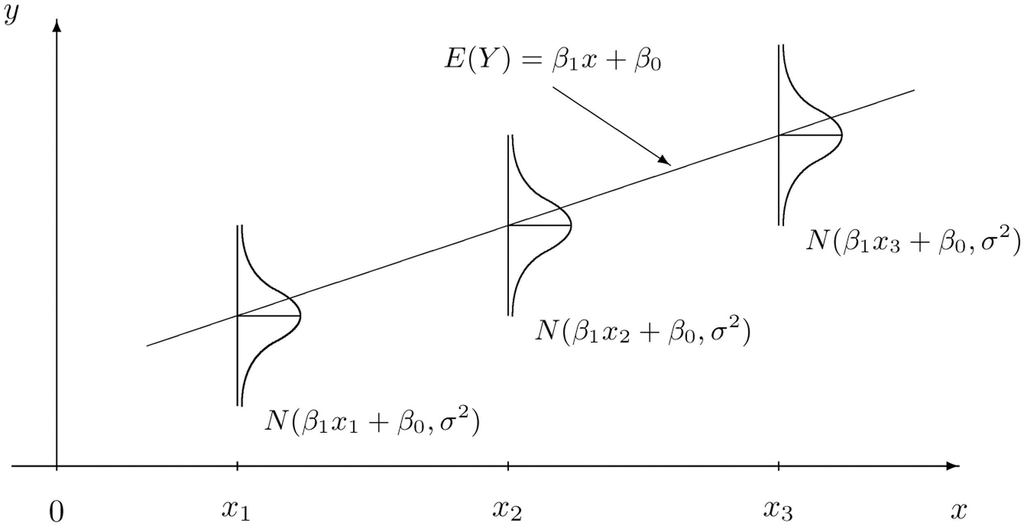

Simple Linear Regression Model UC David Stat Wiki

TODO: use Y when it is random? TODO: make a note that $y_i$ is a data point. $Y_i$ is a random variable. TODO: $x_i$ are fixed, known constants. (Technically and assumption.)

$$y = f(x) + \epsilon$$

$$y = \beta_0 + \beta_1 x + \epsilon$$

PARAMETERS

DATA = PREDICTION + ERRORS = SIGNAL + NOISE = MODEL + ERROR

Unexplained:

- missing variables
- measurement error

ASSUMPTIONS: **LINE**

- **L**inear
- **I**ndepedent
- **N**ormal
- **E**qual Variance

## What is the Best Line?

Goldilocks:

- Underfitting (Just using y_bar)
- Just right (SLR)
- Overfitting (Connect the dots as much as possible.)

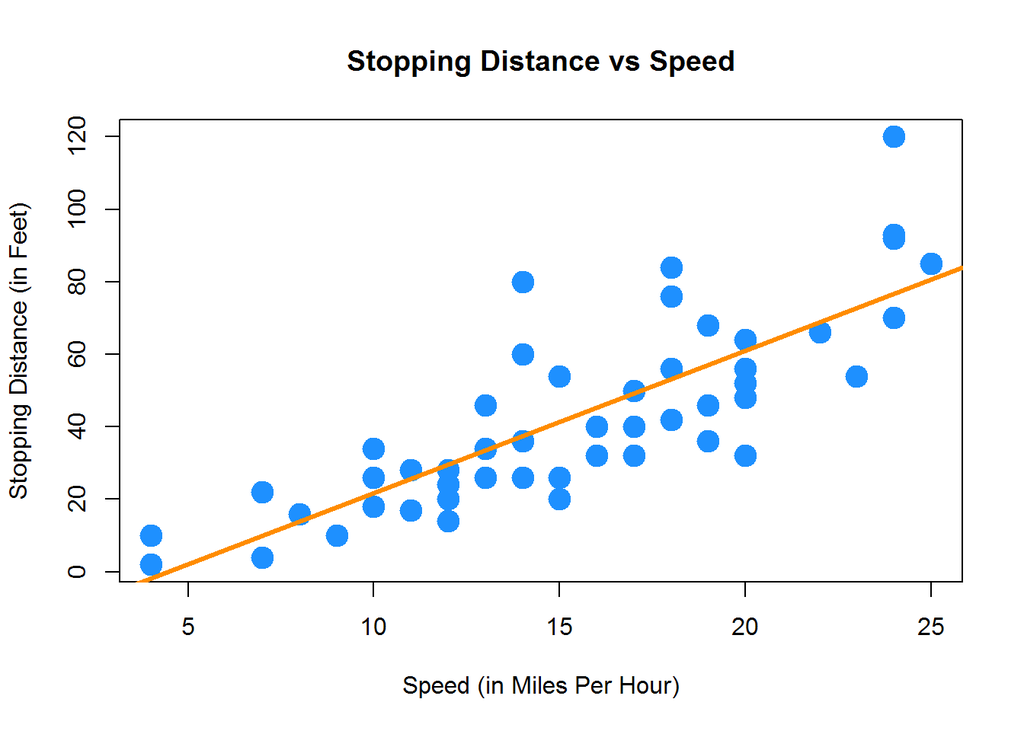

```r
#par(mfrow = c(1, 3))
plot(dist ~ speed, data = cars,
     xlab = "Speed (in Miles Per Hour)",
     ylab = "Stopping Distance (in Feet)",
     main = "Stopping Distance vs Speed",
     pch  = 20,
     cex  = 3,
     col  = "dodgerblue")
abline(stop_dist_model, lwd = 3, col = "darkorange")
```

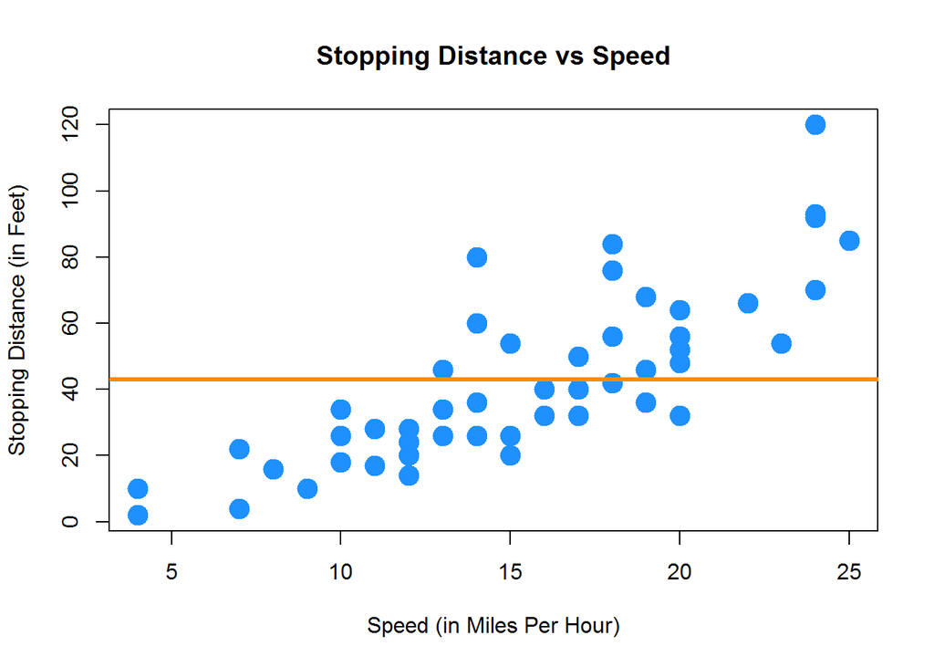

```r
plot(dist ~ speed, data = cars,
     xlab = "Speed (in Miles Per Hour)",
     ylab = "Stopping Distance (in Feet)",
     main = "Stopping Distance vs Speed",
     pch  = 20,
     cex  = 3,
     col  = "dodgerblue")
underfit_model = lm(dist ~ 1, data = cars)
abline(underfit_model, lwd = 3, col = "darkorange")
```

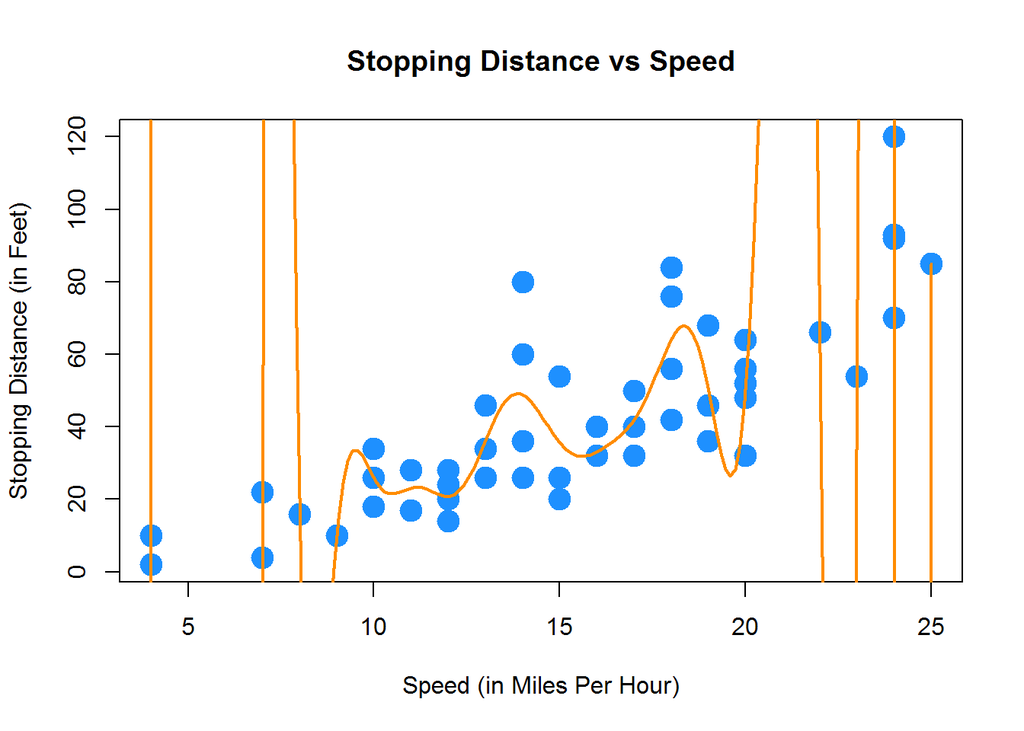

```r
overfit_model = lm(dist ~ poly(speed, 18), data = cars)
x = seq(0, 25, length.out = 200)
plot(dist ~ speed, data = cars,
     xlab = "Speed (in Miles Per Hour)",
     ylab = "Stopping Distance (in Feet)",
     main = "Stopping Distance vs Speed",
     pch  = 20,
     cex  = 3,
     col  = "dodgerblue")
lines(x, predict(overfit_model, data.frame(speed = x)), lwd = 2, col = "darkorange")
```

```r
# add a wild prediction here?
```

$$\underset{\beta_0, \beta_1}{\mathrm{argmin}} \max|y_i - (\beta_0 + \beta_1 x_i)|$$

$$\underset{\beta_0, \beta_1}{\mathrm{argmin}} \sum_{i = 1}^{n}|y_i - (\beta_0 + \beta_1 x_i)|$$

$$\underset{\beta_0, \beta_1}{\mathrm{argmin}} \sum_{i = 1}^{n}(y_i - (\beta_0 + \beta_1 x_i))^2$$

historical, easy math

## Least Squares Approach

We want to find values of $\beta_0$ and $\beta_1$ which minimimize

$$f(\beta_0, \beta_1) = \sum_{i = 1}^{n}(y_i - (\beta_0 + \beta_1 x_i))^2 = \sum_{i = 1}^{n}(y_i - \beta_0 - \beta_1 x_i)^2.$$

We will call these values $\hat{\beta}_0$ and $\hat{\beta}_1$.

Take derivatives.

$$\begin{aligned}
\frac{df}{d\beta_0} &= -2 \sum_{i = 1}^{n}(y_i - \beta_0 - \beta_1 x_i) \\
\frac{df}{d\beta_1} &= -2 \sum_{i = 1}^{n}(x_i)(y_i - \beta_0 - \beta_1 x_i)
\end{aligned}$$

Set equal to zero.

$$\begin{aligned}
\sum_{i = 1}^{n}(y_i - \beta_0 - \beta_1 x_i) &= 0 \\
\sum_{i = 1}^{n}(x_i)(y_i - \beta_0 - \beta_1 x_i) &= 0
\end{aligned}$$

Rearrange, **normal equations**.

$$\begin{aligned}
\sum_{i = 1}^{n} y_i &= n \beta_0 + \beta_1 \sum_{i = 1}^{n} x_i \\
\sum_{i = 1}^{n} x_i y_i &= \beta_0 \sum_{i = 1}^{n} x_i + \beta_1 \sum_{i = 1}^{n} x_i^2
\end{aligned}$$

$$\begin{aligned}
\hat{\beta}_1 &= \frac{\sum_{i = 1}^{n} x_i y_i - \frac{(\sum_{i = 1}^{n} x_i)(\sum_{i = 1}^{n} y_i)}{n}}{\sum_{i = 1}^{n} x_i^2 - \frac{(\sum_{i = 1}^{n} x_i)^2}{n}} = \frac{SXY}{SXX}\\
\hat{\beta}_0 &= \bar{y} - \hat{\beta}_1 \bar{x}
\end{aligned}$$

$$\begin{aligned}
SXY &= \sum_{i = 1}^{n} x_i y_i - \frac{(\sum_{i = 1}^{n} x_i)(\sum_{i = 1}^{n} y_i)}{n} = \sum_{i = 1}^{n}(x_i - \bar{x})(y_i - \bar{y})\\
SXX &= \sum_{i = 1}^{n} x_i^2 - \frac{(\sum_{i = 1}^{n} x_i)^2}{n} = \sum_{i = 1}^{n}(x_i - \bar{x})^2\\
SYY &= \sum_{i = 1}^{n} y_i^2 - \frac{(\sum_{i = 1}^{n} y_i)^2}{n} = \sum_{i = 1}^{n}(y_i - \bar{y})^2
\end{aligned}$$

$$\hat{\beta}_1 = \frac{SXY}{SXX} = \frac{\sum_{i = 1}^{n}(x_i - \bar{x})(y_i - \bar{y})}{\sum_{i = 1}^{n}(x_i - \bar{x})^2}$$

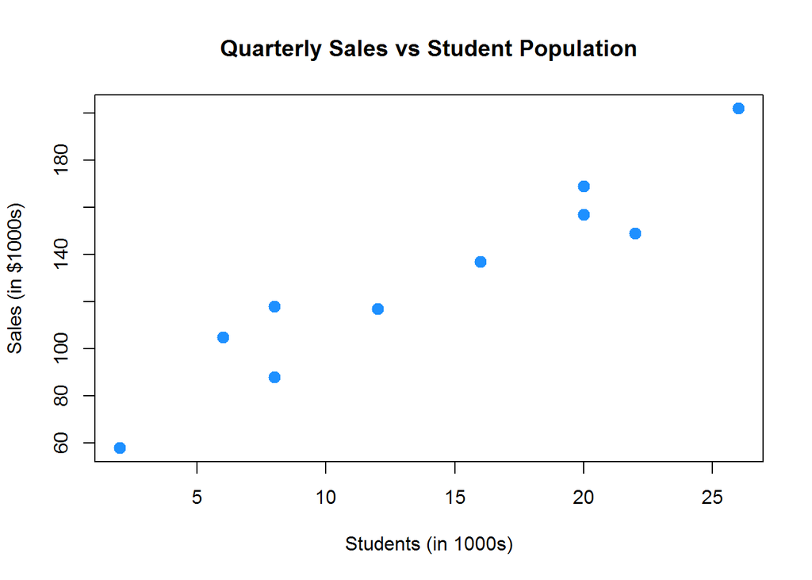

```r
plot(sales ~ students, data = momma_leona,
     xlab = "Students (in 1000s)",
     ylab = "Sales (in $1000s)",
     main = "Quarterly Sales vs Student Population",
     pch  = 20,
     cex  = 2,
     col  = "dodgerblue")
```

## Coefficient of Determination

$R^2$

$$\sum_{i=1}^{n}(y_i - \bar{y})^2 = \sum_{i=1}^{n}(y_i - \hat{y}_i)^2 + \sum_{i=1}^{n}(\hat{y}_i - \bar{y})^2$$

Decomposing variation.

## MLE Approach

$$L(\beta_0, \beta_1, \sigma^2) = \prod_{i = 1}^{n} \frac{1}{\sqrt{2\pi\sigma^2}} \exp{\left[-\frac{1}{2}\left(\frac{Y_i - \beta_0 - \beta_1 x_i}{\sigma}\right)^2\right]}$$

## Basic Simulation? (Save for inference chapter?)

TODO: tie this into the model section? w.r.t. b0 + b1x + e

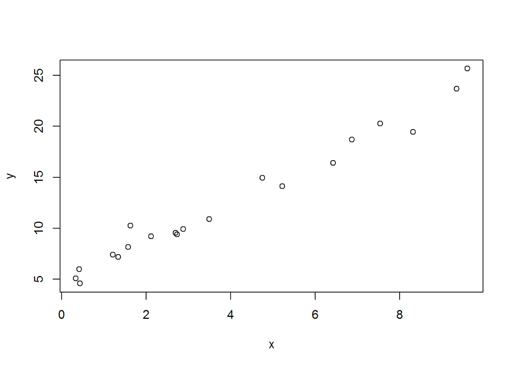

```r
n       = 20
beta_0  = 5
beta_1  = 2
sigma   = 1
epsilon = rnorm(n, mean = 0, sd = sigma)

x = runif(n, 0, 10)
y = beta_0 + beta_1 * x + epsilon

sim_data = data.frame(x, y)
plot(y ~ x, data = sim_data)
```

```r
sim_fit = lm(y ~ x, data = sim_data)
coef(sim_fit)
```

```
## (Intercept)           x
##    4.631268    2.005878
```

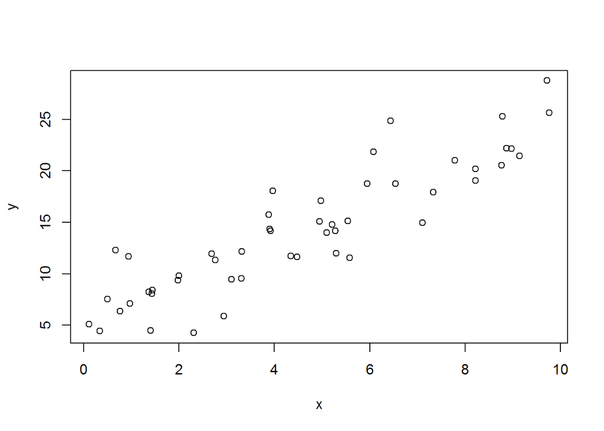

```r
sim_slr = function(n, beta_0 = 10, beta_1 = 5, sigma = 1) {
  epsilon = rnorm(n, mean = 0, sd = sigma)
  x       = runif(n, 0, 10)
  y       = beta_0 + beta_1 * x + epsilon
  data.frame(x, y)
}
sim_data = sim_slr(n = 50, beta_0 = 5, beta_1 = 2, sigma = 3)
plot(y ~ x, data = sim_data)
```

```r
sim_fit = lm(y ~ x, data = sim_data)
coef(sim_fit)
```

```
## (Intercept)           x
##    5.289529    1.951599
```